# Proyecto2_py

## Curso de introducción a la programación con Python

**Autor: Luis Fernando Apáez Álvarez**  
-Curso PyM-  
Proyecto 2: Introducción al análisis de datos  
Fecha: 03 de Septiembre del 2022

## Proyecto 1

#### Contenido:

Recapitulación de la información

Carga y preparación

Primeras observaciones

Taller y SD

Asistencia de los participantes

Gráfico de las asistencias

**Librerías** que ocuparemos en este proyecto:

- Pandas
- Matplotlib

### Recapitulación de la información

Dentro de este proyecto iremos trabajando paso a paso enfocándonos en el análisis de datos.

La información con la que trabajaremos corresponde a los datos generados en la primer semana del curso propedéutico 2023-1 impartido por la Facultad de Ciencias de la UNAM. Dentro de dicho curso se dieron diferentes talleres de diferentes temas.

Ahora bien, para la información recopilada consideraremos dos archivos csv:

- **Encuestas**: Recopila información sobre los diferentes talleres brindados, donde las preguntas evalúan qué tan claro fue la exposición de los temas, el lenguaje que se ocupó, etcétera. De manera global las encuestas evalúan los talleres. Además, el curso estuvo conformado por talleres, donde se veían los temas de una manera intuitiva y sencilla, y por secuencias didácticas (SD), donde se veían los temas del taller pero de una manera más especifica y técnica. En las encuestas se evalúan tanto los talleres como las SD's.
- **Asistencias**: Recopila la asistencia de los participantes del curso propedéutico en la primer semana del curso (es decir, recopila las asistencias de 5 días).

Con base en lo anterior, es natural enfocar nuestro análisis de datos en ver las evaluaciones que se les dieron a cada uno de los talleres, o ver de manera global la evalución conjunta de todos los talleres para determinar una evalución general al curso propedéutico. Podremos ver también cuáles fueron los aspectos (o preguntas de la encuesta) que obtuvieron mejor o peor respuesta; por ejemplo, si logramos identificar las preguntas de la encuesta que obtuvieron peor respuesta, se puede enfocar más en dicho tema o abordarlo de una manera distinta en los siguientes cursos propedéuticos. En teoría, cada participante debía responder sólo una vez la encuesta en dicha primer semana.

Asimismo, podemos ver el comportamiento de los participantes entorno a sus asistencias. Por ejemplo, puede ser que el día viernes asistieron menos participantes a los talleres respecto a los demás días, o tal vez, el día en que asistieron más participantes fue, justamente, el primer día del curso (lunes). Lo anterior podremos responderlo de una manera certera.

Así, lo dicho antes representa el punto de partida y el camino que debemos seguir respecto a nuestro análisis de datos.

### Carga y preparación

Comenzamos por cargar los datos de las encuestas

```python
# Librerias que ocuparemos
import pandas as pd
import matplotlib.pyplot as plt
import numpy as np

# Cargaremos el archivo Encuestas.csv de la web y lo convertiremos
# en un dataframe denominado encuestas
encuestas = pd.read_csv('https://cursopypagina.github.io/CursoPy/Encuestas.csv')

# Vemos los primeros registros
encuestas.head(2)
```

|  | Unnamed: 0 | Marca temporal | Dirección de correo electrónico | Escribe el nombre del taller | El lenguaje de los taller fue adecuado | Se distinguió los objetivos del taller | Fueron claras las instrucciones de los talleres | ¿Qué tan ameno te pareció el taller? | Los talleres te motivaron a seguir indagando en el tema | Si tienes comentarios y/o sugerencias acerca de los talleres son bienvenidos. | El lenguaje de las secuencias didácticas te pareció apropiado | Se distinguió los objetivos de las secuencias didácticas | Fueron claros los conceptos que se formalizaron en las secuencias didácticas | ¿Qué tan complicado te pareció la formalización de los conceptos en las secuencias didácticas? | ¿Qué tan apropiado fue introducir los conceptos formales a partir de los talleres? | Si tienes comentarios y/o sugerencias son bienvenidos | El lenguaje de los talleres fue adecuado | Se distinguieron los objetivos del taller |
| --- | --- | --- | --- | --- | --- | --- | --- | --- | --- | --- | --- | --- | --- | --- | --- | --- | --- | --- |
| 0 | 0 | 21/07/2022 9:16:50 | NaN | Serpientes estocásticas y escaleras aleatorias | 1.0 | 1.0 | 1 | 1 | 2 | Sería bueno si pudieran sugerir bibliografía ú... | Mucho | Mucho | Mucho | Poco | Poco | . | NaN | NaN |
| 1 | 1 | 21/07/2022 9:18:07 | NaN | Serpientes estocásticas y escaleras aleatorias | 1.0 | 1.0 | 2 | 1 | 1 | En general el taller fue ameno, la actividad d... | Mucho | Mucho | Mucho | Mucho | Mucho | No tengo mucho que agregar, me pareció bastant... | NaN | NaN |

Para trabajar con mayor facilidad cambiaremos el nombre de las columnas

```python
# Vemos la forma del dataframe
print(encuestas.shape)
print("-" * 100)

# Almacenaremos el numero total de columnas
# en la siguiente variable
ncols = encuestas.shape[1]

# Nombres originales de las columnas
ncolumnas = encuestas.columns
print(ncolumnas)
print("-" * 100)

# Los nuevos nombres seran numeros para trabajar de una
# manera mas facil
encuestas.columns = [str(i) for i in range(ncols)]
print("Nuevos nombres de las columnas: ")
print(encuestas.columns)
print("-" * 100)

# Creamos una lista de tuplas de la asociacion que acabamos de realizar
# esto es, en las primeras entradas de la tuplas estaran los numeros
# de las columnas como los asignamos antes, y en las segundas entradas
# los nombres originales de las columnas
name_columns = []
for i in range(ncols):
    tupla = (str(i), ncolumnas[i])
    name_columns.append(tupla)
display(name_columns)
```

```
(145, 18)
----------------------------------------------------------------------------------------------------
Index(['Unnamed: 0', 'Marca temporal', 'Dirección de correo electrónico',
       'Escribe el nombre del taller ',
       'El lenguaje de los taller fue adecuado ',
       'Se distinguió los objetivos del taller',
       'Fueron claras las instrucciones de los talleres',
       '¿Qué tan ameno te pareció el taller?',
       'Los talleres te motivaron a seguir indagando en el tema',
       'Si tienes comentarios y/o sugerencias acerca de los talleres son bienvenidos.',
       'El lenguaje de las secuencias didácticas te pareció apropiado',
       'Se distinguió los objetivos de las secuencias didácticas',
       'Fueron claros los conceptos que se formalizaron en las secuencias didácticas',
       '¿Qué tan complicado te pareció la formalización de los conceptos en las secuencias didácticas?',
       '¿Qué tan apropiado fue introducir los conceptos formales a partir de los talleres?',
       'Si tienes comentarios y/o sugerencias son bienvenidos',
       'El lenguaje de los talleres fue adecuado ',
       'Se distinguieron los objetivos del taller'],
      dtype='object')
----------------------------------------------------------------------------------------------------
Nuevos nombres de las columnas:
Index(['0', '1', '2', '3', '4', '5', '6', '7', '8', '9', '10', '11', '12',
       '13', '14', '15', '16', '17'],
      dtype='object')
----------------------------------------------------------------------------------------------------
```

```
[('0', 'Unnamed: 0'),
 ('1', 'Marca temporal'),
 ('2', 'Dirección de correo electrónico'),
 ('3', 'Escribe el nombre del taller '),
 ('4', 'El lenguaje de los taller fue adecuado '),
 ('5', 'Se distinguió los objetivos del taller'),
 ('6', 'Fueron claras las instrucciones de los talleres'),
 ('7', '¿Qué tan ameno te pareció el taller?'),
 ('8', 'Los talleres te motivaron a seguir indagando en el tema'),
 ('9',
  'Si tienes comentarios y/o sugerencias acerca de los talleres son bienvenidos.'),
 ('10', 'El lenguaje de las secuencias didácticas te pareció apropiado'),
 ('11', 'Se distinguió los objetivos de las secuencias didácticas'),
 ('12',
  'Fueron claros los conceptos que se formalizaron en las secuencias didácticas'),
 ('13',
  '¿Qué tan complicado te pareció la formalización de los conceptos en las secuencias didácticas?'),
 ('14',
  '¿Qué tan apropiado fue introducir los conceptos formales a partir de los talleres?'),
 ('15', 'Si tienes comentarios y/o sugerencias son bienvenidos'),
 ('16', 'El lenguaje de los talleres fue adecuado '),
 ('17', 'Se distinguieron los objetivos del taller')]
```

Podemos notar que la columna 0 (`'Unnamed: 0'`) y la columna 1 no nos aportan información relevante para el análisis que buscamos hacer. Luego, la columna 2 tiene en todas sus entradas el valor `NaN`. Para comprobar lo anterior ocuparemos el método `unique()` el cual nos arroja todos los valores diferentes que están almacenados en una columna

```python
encuestas['2'].unique()
```

```
array([nan])
```

entonces sólo hay un valor distinto almacenado en dicha columna, esto es, todos los valores en la columna `2` tienen el valor `NaN`.

Otro ejemplo utilizando `unique()` es al hallar todos los nombres de los distintos talleres del curso:

```python
encuestas['3'].unique()
```

```
array(['Serpientes estocásticas y escaleras aleatorias',
       'Serpientes estocásticas y escaleras aleatorias.',
       'Lógica y sudokus', 'Lógica, sudokus y...¿demostraciones?',
       'Cartas en Set', 'Sudoku', 'Bingo del multiverso ',
       ' Bingo del Multiverso. ', 'Bingo del Multiverso',
       'Bingo del Multiverso ', 'Bingo del multiverso',
       'bingo del multiiverso', 'Curso Propedeutico',
       'Juntos con Conujntos', 'Juntos con conjuntos',
       'juntos con conjuntos ', 'Juntos con Conjuntos',
       'Junto con Conjuntos', 'Juntos con conjuntos ', 'Conjuntos ?',
       'Probabilidad ', 'Carrera de probabilidades con Mario Kart',
       'carrera de probabilidades con Mario Kart ',
       'Carrera de probabilidad con Mario Kart',
       'Carrera de Probabilidades', 'Carrera de Probabilidad',
       'Mario Kart y probabilidades ',
       'Carrera de Probabilidades con Mario Kart.',
       'carrera de probabilidades con Mario kart ',
       'Los caminos del infinito (no son como yo pensaba).',
       'Los caminos del infinito (no son como yo pensaba)',
       'Los caminos del infinito (no son lo que yo pensaba).',
       'Los caminos del infinito (no son lo que yo pensaba)',
       'Los caminos del infinito (no son como yo pensaba). ',
       'Los caminos del infinito',
       'Los caminos del infinito no son lo que yo pensaba',
       'Probabilidad, con Mario kart ', 'Aliens mentirosos',
       'Cursos Propedéuticos Facultad de Ciencias ',
       'Secuencias didacticas', 'Curso Propedéutico Facultad de Ciencias',
       'Aliens Mentirosos', 'Aliens mentirosos.', 'Aliens mentirosos ',
       'Un algoritmo para calcular el día del fin del mundo ',
       'un algoritmo para calcular el fin del mundo',
       'El algoritmo para calcular el fin del mundo. ',
       'Un algoritmo para calcular el fin del mundo',
       'Un algoritmo para calcular el día del fin del mundo',
       'Ecuación para calcular el fin del mundo',
       'Un algoritmo para calcular el fin del mundo ',
       'Juego del grafimar', 'el juego del grafimar',
       'Juego del Grafimar  (Teoría de Grafos)', 'El juego del Grafimar',
       'Juego del grafimar ', 'El juego del grafimar ',
       'El juego del grafimar', 'Juego del Grafimar',
       'Juego del Grafimar G10', '¿Leonardo Di Caprio es perfecto?',
```

[output cut: 12 more lines]

```
       'Maquina de cafe para hacer teoremas¿',
       'Maquina para transformar cafe en teoremas ',
       'Maquina para transformar café en teoremas',
       'Máquina para transformar café en teoremas. ',
       'Máquina para transformar café en teoremas ',
       'Máquina para transformas café en teoremas. ',
       'No lo recuerdo, ya que el link que me mandaron al principio me mandaba a un equipo que no era el mío entonces creo que me perdí eso ',
       'Toros y vacas ', 'Vacas y toros', 'toros y vacas', 'Toros vacas ',
       'Toros y Vacas', 'Propedeutico ',
       'Máquina para transformas café en teoremas',
       'Màquina para transformar café en teoremas',
       'maquina para transformar café en teoremas',
       'Maquina para transformar café en teoremas.',
       'Maquina para transformar cafe en  teoremas', 'TOROS Y VACAS',
       'maquina para transformar café en teoremas '], dtype=object)
```

lo cual más o menos resulta como queríamos, solo que los estudiantes ingresaron de diferentes maneras el nombre de un mismo taller. Para obtener tal cual el resultado que queríamos tendríamos que realizar una limpieza de datos sobre dicha columna, lo cual no haremos.

El punto es que la columna 2 solo tiene el valor `NaN` repetido, por lo cual también la eliminaremos.

Para eliminar un columna o fila utilizaremos el método `drop(<columnas o filas>, axis=)` donde colocaremos en el primer parámetro la columna o fila (o una lista de columnas o filas) que queramos eliminar, y asignaremos el valor de `axis=1` cuando queramos eliminar columnas o `axis=0` cuando queramos eliminar filas. De tal manera:

```python
# Eliminaremos las columnas 0, 1 y 2
encuestas = encuestas.drop(['0','1','2'], axis=1)
encuestas.head(2)
```

|  | 3 | 4 | 5 | 6 | 7 | 8 | 9 | 10 | 11 | 12 | 13 | 14 | 15 | 16 | 17 |
| --- | --- | --- | --- | --- | --- | --- | --- | --- | --- | --- | --- | --- | --- | --- | --- |
| 0 | Serpientes estocásticas y escaleras aleatorias | 1.0 | 1.0 | 1 | 1 | 2 | Sería bueno si pudieran sugerir bibliografía ú... | Mucho | Mucho | Mucho | Poco | Poco | . | NaN | NaN |
| 1 | Serpientes estocásticas y escaleras aleatorias | 1.0 | 1.0 | 2 | 1 | 1 | En general el taller fue ameno, la actividad d... | Mucho | Mucho | Mucho | Mucho | Mucho | No tengo mucho que agregar, me pareció bastant... | NaN | NaN |

### Primeras observaciones

Cada fila del dataframe corresponde a un participante que contestó la encuesta, de modo que podemos ver cuántos alumnos respondieron la encuesta:

```python
# Numero de participantes que respondieron la encuesta
encuestas.shape[0]
```

```
145
```

Veamos el tipo de dato de cada una de las columnas del dataframe de `encuestas`, para lo cual nos auxiliamos del método `info()`:

```python
# Veamos ahora una breve informacion de nuestro dataframe
encuestas.info()
```

```
<class 'pandas.core.frame.DataFrame'>
RangeIndex: 145 entries, 0 to 144
Data columns (total 15 columns):
 #   Column  Non-Null Count  Dtype
---  ------  --------------  -----
 0   3       145 non-null    object
 1   4       133 non-null    float64
 2   5       133 non-null    float64
 3   6       145 non-null    int64
 4   7       145 non-null    int64
 5   8       145 non-null    int64
 6   9       145 non-null    object
 7   10      145 non-null    object
 8   11      145 non-null    object
 9   12      145 non-null    object
 10  13      145 non-null    object
 11  14      145 non-null    object
 12  15      145 non-null    object
 13  16      12 non-null     float64
 14  17      12 non-null     float64
dtypes: float64(4), int64(3), object(8)
memory usage: 17.1+ KB
```

Notamos que las columnas 4-8 y 16-17 son numéricas, por lo cual podría ser de nuestro interés ver algunas estadísticas sobre dichas columnas:

```python
encuestas.describe()
```

|  | 4 | 5 | 6 | 7 | 8 | 16 | 17 |
| --- | --- | --- | --- | --- | --- | --- | --- |
| count | 133.000000 | 133.000000 | 145.000000 | 145.000000 | 145.000000 | 12.000000 | 12.000000 |
| mean | 1.593985 | 1.676692 | 1.510345 | 1.606897 | 1.668966 | 1.166667 | 1.333333 |
| std | 1.161488 | 1.158296 | 1.093651 | 1.144410 | 1.074032 | 0.389249 | 0.651339 |
| min | 1.000000 | 1.000000 | 1.000000 | 1.000000 | 1.000000 | 1.000000 | 1.000000 |
| 25% | 1.000000 | 1.000000 | 1.000000 | 1.000000 | 1.000000 | 1.000000 | 1.000000 |
| 50% | 1.000000 | 1.000000 | 1.000000 | 1.000000 | 1.000000 | 1.000000 | 1.000000 |
| 75% | 2.000000 | 2.000000 | 1.000000 | 2.000000 | 2.000000 | 1.000000 | 1.250000 |
| max | 5.000000 | 5.000000 | 5.000000 | 5.000000 | 5.000000 | 2.000000 | 3.000000 |

```python
# Veamos los nombres de algunas columnas de interes
name_columns[4:9]
```

```
[('4', 'El lenguaje de los taller fue adecuado '),
 ('5', 'Se distinguió los objetivos del taller'),
 ('6', 'Fueron claras las instrucciones de los talleres'),
 ('7', '¿Qué tan ameno te pareció el taller?'),
 ('8', 'Los talleres te motivaron a seguir indagando en el tema')]
```

vemos que, para la pregunta: ¿El lenguaje de los taller fue adecuado? En promedio (`mean`) se obtuvo una buena calificación (recordemos que 1 es una muy buena calificación y 5 una muy mala); vemos también que el 75% de los datos tienen un valor asociado (en la columna `4`) menor a 2, lo que quiere decir, prácticamente, que el 75% de los alumnos dió una muy buena calificación respecto a dicha pregunta, esto es, podemos concluir que en general el lenguaje de los talleres fue adecuado.

De la misma manera, para el resto de las preguntas a considerar

```
 ('5', 'Se distinguió los objetivos del taller')
 ('6', 'Fueron claras las instrucciones de los talleres')
 ('7', '¿Qué tan ameno te pareció el taller?')
 ('8', 'Los talleres te motivaron a seguir indagando en el tema')
```

obtenemos resultados similares, y por tanto buenas calificaciones, en general, para todos los talleres impartidos.

Para las columnas `16` y `17` tendríamos que realizar un análisis a parte.

### Taller y SD

Ahora bien, las preguntas de las columnas de la 4 a la 8 serán respondidas por un número entre el 1 y el 5, donde 1 representa la idea "Mucho" y el 5 representa la idea "Poco". Las preguntas de la 10 a la 14 son respondidas únicamente con la etiqueta "Mucho" o "poco".

Lo que haremos ahora a partir de las preguntas será realizar un gráfico para visualizar de mejor manera cómo fueron calificados los distintos talleres y secuencias didácticas (SD), algo como

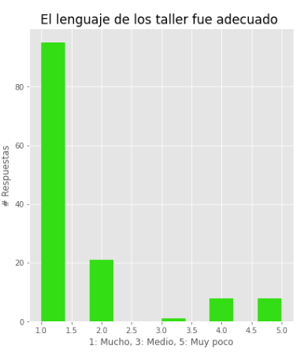

Así, lo que haremos será construir el gráfico anterior

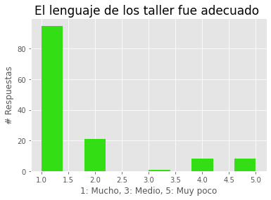

```python
plt.style.use('ggplot')
# Recordemos que la columna 4 tiene asociada
# la pregunta:
# El lenguaje de los taller fue adecuado

# Utilizaremos un histograma para realizar el grafico
# para lo cual escribiremos plt.hist() como sigue:
plt.hist(encuestas['4'], color="#34DE14")

# Etiquetas y titulo
plt.xlabel("1: Mucho, 3: Medio, 5: Muy poco", size=12)
plt.ylabel("# Respuestas")
plt.title(name_columns[4][1], size=17)

# Mostramos el grafico
plt.show()
```

Obteniéndose así el gráfico que queríamos. Continuando, ahora mostraremos los gráficos pero del resto de las preguntas. Configuraremos la salida de nuestros gráficos para que se muestren juntos, para lo cual utilizaremos `plt.subplot(n,k,j)` donde:

- n: establece el número de filas de nuestro gráfico;
- k: establece el número de columnas de nuestro gráfico;
- j: establece el número del gráfico que ocupará un subgráfico en particular;

Por ejemplo:

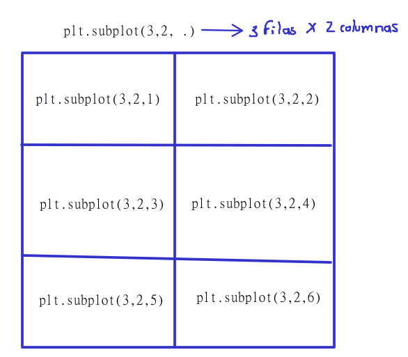

De tal manera

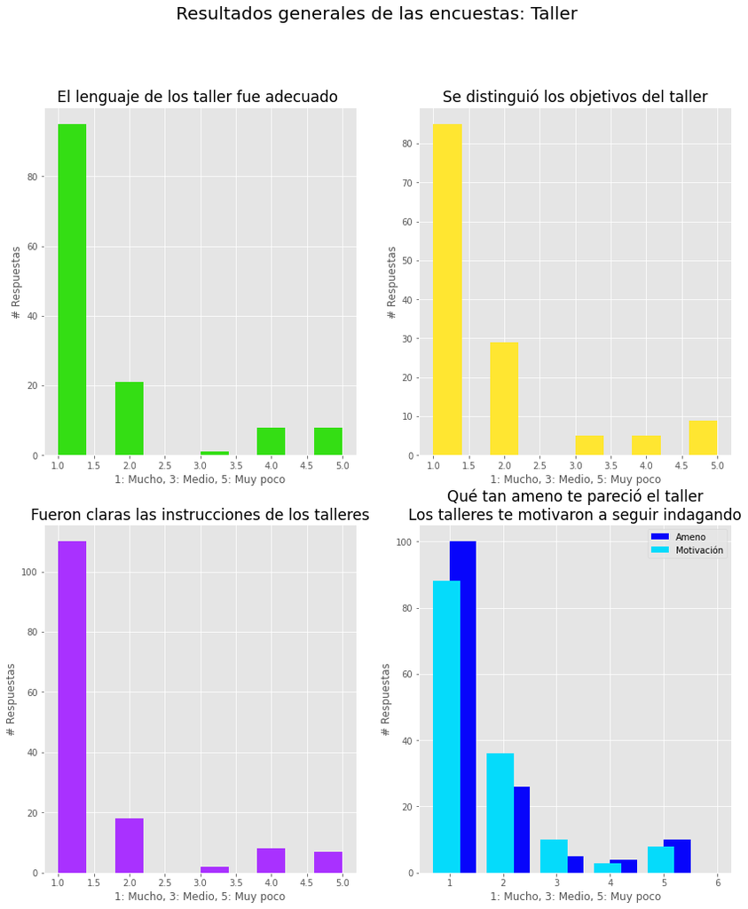

```python
plt.style.use('ggplot')
# Configuramos el tamanio total del grafico
# (14 px de largo por 16 px de ancho)
fig = plt.figure(figsize=(14,16))

# Primer grafico:
plt.subplot(2,2,1)
plt.hist(encuestas['4'], color="#34DE14")
plt.xlabel("1: Mucho, 3: Medio, 5: Muy poco", size=12)
plt.ylabel("# Respuestas")
plt.title(name_columns[4][1], size=17)

# Segundo grafico:
plt.subplot(2,2,2)
plt.hist(encuestas['5'], color="#FFE631")
plt.xlabel("1: Mucho, 3: Medio, 5: Muy poco", size=12)
plt.ylabel("# Respuestas")
plt.title(name_columns[5][1], size=17)

# Tercer grafico:
plt.subplot(2,2,3)
plt.hist(encuestas['6'], color="#A931FF")
plt.xlabel("1: Mucho, 3: Medio, 5: Muy poco", size=12)
plt.ylabel("# Respuestas")
plt.title(name_columns[6][1], size=17)

# Cuarto grafico
plt.subplot(2,2,4)
# Aqui juntaremos dos histogramas en un solo subgrafico
# correspondientes a las preguntas
# ¿Qué tan ameno te parecio el taller? (7) y
# Los talleres te motivaron a seguir indagando en el tema (8)
#                                       configuramos un rango
#                                       de graficacion refe-
#                                       rente al eje x
plt.hist(encuestas['7'], color="#0705FB", range=(1,6))
plt.hist(encuestas['8'], color='#05DBFB', range=(0.7,5.7))
plt.xlabel("1: Mucho, 3: Medio, 5: Muy poco", size=12)
plt.ylabel("# Respuestas")
# Configuramos plt.legend() para distinguir entre los dos histogramas
plt.legend(["Ameno", "Motivación"])
plt.title("Qué tan ameno te pareció el taller\nLos talleres te motivaron a seguir indagando", size=17)

# Titulo del grafico completo
plt.suptitle("Resultados generales de las encuestas: Taller", size=20)
plt.show()
```

Observamos que, en general, todos los talleres del curso obtuvieron una calificación buena. En más detalle:

1. En general el lenguaje de los talleres fue muy adecuado.
2. En general los objetivos de los talleres fueron altamente distinguibles.
3. En general las instrucciones de los talleres fueron muy claras.
4. En general los talleres fueron muy amenos.
5. La gran mayoría de los alumnos se vieron motivados a seguir investigando sobre el tema abordado en los talleres.

concluyendo así que el curso propedéutico fue bueno.

Realizamos lo mismo pero ahora para la secuencia didáctica. Notemos primero lo siguiente

```python
# Veamos los nombres de algunas columnas de interes
name_columns[10:]
```

```
[('10', 'El lenguaje de las secuencias didácticas te pareció apropiado'),
 ('11', 'Se distinguió los objetivos de las secuencias didácticas'),
 ('12',
  'Fueron claros los conceptos que se formalizaron en las secuencias didácticas'),
 ('13',
  '¿Qué tan complicado te pareció la formalización de los conceptos en las secuencias didácticas?'),
 ('14',
  '¿Qué tan apropiado fue introducir los conceptos formales a partir de los talleres?'),
 ('15', 'Si tienes comentarios y/o sugerencias son bienvenidos'),
 ('16', 'El lenguaje de los talleres fue adecuado '),
 ('17', 'Se distinguieron los objetivos del taller')]
```

las preguntas de la 10 a la 15 corresponden a las secuencias didácticas, y de la 16 a la 17 son errores pues dichas preguntas fueron abordadas en columnas anteriores. De modo que sólo consideraremos las columnas de la 10 a la 15. Además, dichas preguntas se contestaron ahora sólo con dos etiquetas posibles: Mucho o Poco. Por ende, para analizarlas de una manera más sencilla convertiremos la etiqueta Mucho al valor 1 y la etiqueta Poco al valor 0. Notemos el dataframe concentrándonos en las columnas de la 10 a al 14

```python
encuestas[['10','11','12','13','14']]
```

|  | 10 | 11 | 12 | 13 | 14 |
| --- | --- | --- | --- | --- | --- |
| 0 | Mucho | Mucho | Mucho | Poco | Poco |
| 1 | Mucho | Mucho | Mucho | Mucho | Mucho |
| 2 | Mucho | Mucho | Mucho | Mucho | Mucho |
| 3 | Mucho | Mucho | Mucho | Poco | Mucho |
| 4 | Mucho | Mucho | Mucho | Poco | Mucho |
| ... | ... | ... | ... | ... | ... |
| 140 | Mucho | Mucho | Mucho | Poco | Mucho |
| 141 | Mucho | Mucho | Mucho | Mucho | Mucho |
| 142 | Mucho | Mucho | Mucho | Poco | Mucho |
| 143 | Mucho | Mucho | Mucho | Poco | Mucho |
| 144 | Mucho | Mucho | Mucho | Poco | Mucho |

145 rows × 5 columns

Para hacer el cambio de Mucho a 1 y de Poco a 0 dentro de nuestro dataframe, utilizaremos el método `replace()` auxiliándonos de diccionarios. Primero crearemos un diccionario donde las *keys* serán los valores que tiene una determinada columna. Por ejemplo, la columna `10` tiene por valores a `Mucho` y a `Poco`, de modo que dichos valores serán las *keys* del diccionario que crearemos. Luego, los *values* asociados a dichas *keys* serán los valores de reemplazo. Para nuestro ejemplo escribiríamos el siguiente diccionario

```
valores_reemplazo = {'Mucho': 1, 'Poco': 0}
```

pues queremos reemplazar la etiqueta Mucho por el número 1, y la etiqueta Poco con el número 0.

Una vez que tenemos el diccionario para efectuar los reemplazos, debemos definir otro diccionario en el cual las *keys* serán las columnas donde haremos el reemplazo de los valores, y los *values* asociados serán diccionarios con las asociaciones de reemplazo. En nuestro ejemplo, si queremos cambiar los valores de la columna `10`, entonces el `10` será una *key* de este último diccionario y su *value* asociado es el diccionario que definimos antes `valores_reemplazo`. De tal manera, para efectuar el cambio que deseamos escribimos

```
encuestas.replace({'10': valores_reemplazo})
```

para conseguir el reemplazo que queremos. Dado que el cambio queremos realizarlo en más de una columna, entonces escribiremos:

```python
# Mucho --> 1
# Poco --> 0
valores_reemplazo = {'Mucho': 1, 'Poco': 0}

# Realizamos los reemplazos en las columnas de la 10
# a la 14
encuestas = encuestas.replace({'10': valores_reemplazo,
                               '11': valores_reemplazo,
                               '12': valores_reemplazo,
                               '13': valores_reemplazo,
                               '14': valores_reemplazo})
# Veamos los cambios
encuestas[['10','11','12','13','14']]
```

|  | 10 | 11 | 12 | 13 | 14 |
| --- | --- | --- | --- | --- | --- |
| 0 | 1 | 1 | 1 | 0 | 0 |
| 1 | 1 | 1 | 1 | 1 | 1 |
| 2 | 1 | 1 | 1 | 1 | 1 |
| 3 | 1 | 1 | 1 | 0 | 1 |
| 4 | 1 | 1 | 1 | 0 | 1 |
| ... | ... | ... | ... | ... | ... |
| 140 | 1 | 1 | 1 | 0 | 1 |
| 141 | 1 | 1 | 1 | 1 | 1 |
| 142 | 1 | 1 | 1 | 0 | 1 |
| 143 | 1 | 1 | 1 | 0 | 1 |
| 144 | 1 | 1 | 1 | 0 | 1 |

145 rows × 5 columns

Continuando, escribiremos un código para poder realizar los gráficos de barras correspondientes para ver cómo fueron calificados, ahora, las secuencias didácticas. El código será totalmente análogo al que se empleó para los gráficos de las preguntas de los talleres.

Ahora, el código que escribiremos para crear los gráficos será mediante una función

```python
name_columns[10:15]
```

```
[('10', 'El lenguaje de las secuencias didácticas te pareció apropiado'),
 ('11', 'Se distinguió los objetivos de las secuencias didácticas'),
 ('12',
  'Fueron claros los conceptos que se formalizaron en las secuencias didácticas'),
 ('13',
  '¿Qué tan complicado te pareció la formalización de los conceptos en las secuencias didácticas?'),
 ('14',
  '¿Qué tan apropiado fue introducir los conceptos formales a partir de los talleres?')]
```

```python
# Funcion para graficar la informacion
# de las secuencias
def graficar_secuencias(dataframe):
    """La función recibirá como parámetro un
    dataframe y realizará los gráficos de barras
    para cada una de las preguntas dadas
    en la encuesta para las secuencias
    didácticas.
    Las preguntas de la encuesta para la SD
    son de la 10 a la 14."""

    # Configuramos el tamanio del grafico
    fig = plt.figure(figsize=(12,13))
    plt.subplot(2,2,1)
    # Pregunta 10 SD
    plt.hist(dataframe['10'], color="#02FE0C", bins=3, range=(0,1))
    plt.xticks([0.172, 0.837], ['0: Poco', '1: Mucho'], size=12)
    plt.ylabel("# Respuestas")
    plt.title(" Lenguaje apropiado")

    plt.subplot(2,2,2)
    # Pregunta 11 SD
    plt.hist(dataframe['11'], color="#F747FF", bins=3, range=(0,1))
    plt.xticks([0.172, 0.837], ['0: Poco', '1: Mucho'], size=12)
    plt.ylabel("# Respuestas")
    plt.title("Distinción de objetivos")

    plt.subplot(2,2,3)
    # Pregunta 12 SD
    plt.hist(dataframe['12'], color="#FCB31E", bins=3, range=(0,1))
    plt.xticks([0.172, 0.837], ['0: Poco', '1: Mucho'], size=12)
    plt.ylabel("# Respuestas")
    plt.title(" Conceptos claros en la formalización")

    plt.subplot(2,2,4)
    # Graficamos juntos las graficas de la pregunta 13 y 14
    # Pregunta 13 SD
    plt.hist(dataframe['13'], color="#FF0000", bins=3, range=(0,1))
    # Pregunta 14 SD
    plt.hist(dataframe['14'], color='#05DBFB', bins=3, range=(0,1), alpha=0.8)
    plt.xticks([0.172, 0.837], ['0: Poco', '1: Mucho'], size=12)
    plt.ylabel("# Respuestas")
    plt.legend(["Complicado", "Apropiado"])
    plt.title("Qué tan complicado fue la formaliz\nFue apropiado introducir la formaliz a partir taller",
              size=14)


    plt.suptitle("Resultados generales de las encuestas: SD", size=18)
    plt.show()
```

Ahora bien, utilizaremos la función anterior y le pasaremos el dataframe `encuestas` con el que estamos trabajando

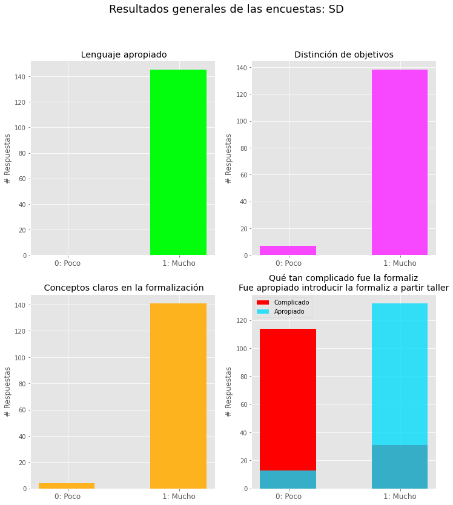

```python
graficar_secuencias(encuestas)
```

De lo anterior podemos decir que:

1. El lenguaje de las secuencias didácticas fue totalmente apropiado.
2. Casi totalmente, la distinción de objetivos fue muy clara.
3. Casi totalmente, fueron muy claros los conceptos que se formalizaron en las secuencias didácticas
4. La gran mayoría dice que la formalización de los conceptos en las secuencias didácticas le pareció poco complicado.
5. La gran mayoría dice que le pareció apropiado la formalización de los conceptos a partir del taller.

### Asistencia de los participantes

Ahora leeremos el archivo `Asistencia.csv` para analizar la asistencia de los participantes en la primer semana del curso propedéutico y ver algunas tendencias.

```python
# Comenzamos por cargar los datos
asistencias = pd.read_csv('https://cursopypagina.github.io/CursoPy/Asistencias.csv')
asistencias.head(2)
```

|  | Unnamed: 0 | Primer apellido | Segundo apellido | Nombre (s) | Email | Email alterno | 2022-07-18 00:00:00 | 2022-07-19 00:00:00 | 2022-07-20 00:00:00 | 2022-07-21 00:00:00 | ... | 2022-07-25 00:00:00 | 2022-07-26 00:00:00 | 2022-07-27 00:00:00 | 2022-07-28 00:00:00 | 2022-07-29 00:00:00 | 2022-08-01 00:00:00 | 2022-08-02 00:00:00 | 2022-08-03 00:00:00 | 2022-08-04 00:00:00 | 2022-08-05 00:00:00 |
| --- | --- | --- | --- | --- | --- | --- | --- | --- | --- | --- | --- | --- | --- | --- | --- | --- | --- | --- | --- | --- | --- |
| 0 | 0 | NaN | NaN | JACIR JEZHAELL | NaN | NaN | 0 | 0 | 1 | 0.0 | ... | NaN | NaN | NaN | NaN | NaN | NaN | NaN | NaN | NaN | NaN |
| 1 | 1 | NaN | NaN | MANUEL ALEJANDRO | NaN | NaN | 0 | 0 | 0 | 0.0 | ... | NaN | NaN | NaN | NaN | NaN | NaN | NaN | NaN | NaN | NaN |

2 rows × 21 columns

```python
print(asistencias.columns)
print(asistencias.shape)
```

```
Index(['Unnamed: 0', 'Primer apellido', 'Segundo apellido', 'Nombre (s)',
       'Email', 'Email alterno', '2022-07-18 00:00:00', '2022-07-19 00:00:00',
       '2022-07-20 00:00:00', '2022-07-21 00:00:00', '2022-07-22 00:00:00',
       '2022-07-25 00:00:00', '2022-07-26 00:00:00', '2022-07-27 00:00:00',
       '2022-07-28 00:00:00', '2022-07-29 00:00:00', '2022-08-01 00:00:00',
       '2022-08-02 00:00:00', '2022-08-03 00:00:00', '2022-08-04 00:00:00',
       '2022-08-05 00:00:00'],
      dtype='object')
(261, 21)
```

Las únicas columnas que serán de nuestro interés son de la `2022-07-18 00:00:00'` a la `'2022-07-22 00:00:00'` que representan los días de la semana del lunes al viernes de cuando se impartió el curso propedéutico. Además, para los fines del análisis que realizaremos, las demás columnas no nos interesarán.

Nuevamente, por comodidad cambiaremos el nombre de las columnas

```python
# Almacenamos los nombres de las columnas
nombres = asistencias.columns

# Cambiamos el nombre de las columnas
asistencias.columns = [str(i) for i in range(21)]

# Creamos una lista de tuplas de la asociacion anterior
names_columns = []
for i in range(21):
    tupla = (str(i), nombres[i])
    names_columns.append(tupla)

display(names_columns)
print("-" * 100)
display(asistencias.head(2))
```

```
[('0', 'Unnamed: 0'),
 ('1', 'Primer apellido'),
 ('2', 'Segundo apellido'),
 ('3', 'Nombre (s)'),
 ('4', 'Email'),
 ('5', 'Email alterno'),
 ('6', '2022-07-18 00:00:00'),
 ('7', '2022-07-19 00:00:00'),
 ('8', '2022-07-20 00:00:00'),
 ('9', '2022-07-21 00:00:00'),
 ('10', '2022-07-22 00:00:00'),
 ('11', '2022-07-25 00:00:00'),
 ('12', '2022-07-26 00:00:00'),
 ('13', '2022-07-27 00:00:00'),
 ('14', '2022-07-28 00:00:00'),
 ('15', '2022-07-29 00:00:00'),
 ('16', '2022-08-01 00:00:00'),
 ('17', '2022-08-02 00:00:00'),
 ('18', '2022-08-03 00:00:00'),
 ('19', '2022-08-04 00:00:00'),
 ('20', '2022-08-05 00:00:00')]
```

|  | 0 | 1 | 2 | 3 | 4 | 5 | 6 | 7 | 8 | 9 | ... | 11 | 12 | 13 | 14 | 15 | 16 | 17 | 18 | 19 | 20 |
| --- | --- | --- | --- | --- | --- | --- | --- | --- | --- | --- | --- | --- | --- | --- | --- | --- | --- | --- | --- | --- | --- |
| 0 | 0 | NaN | NaN | JACIR JEZHAELL | NaN | NaN | 0 | 0 | 1 | 0.0 | ... | NaN | NaN | NaN | NaN | NaN | NaN | NaN | NaN | NaN | NaN |
| 1 | 1 | NaN | NaN | MANUEL ALEJANDRO | NaN | NaN | 0 | 0 | 0 | 0.0 | ... | NaN | NaN | NaN | NaN | NaN | NaN | NaN | NaN | NaN | NaN |

2 rows × 21 columns

notamos que las columnas con la cuales trabajaremos serán de la 6 a la 10:

```python
asistencias[['6', '7', '8', '9', '10']]
```

|  | 6 | 7 | 8 | 9 | 10 |
| --- | --- | --- | --- | --- | --- |
| 0 | 0 | 0 | 1 | 0.0 | 0.0 |
| 1 | 0 | 0 | 0 | 0.0 | 0.0 |
| 2 | 1 | 1 | 1 | 1.0 | 1.0 |
| 3 | 0 | 1 | 1 | 1.0 | 1.0 |
| 4 | 0 | 1 | 1 | 1.0 | 1.0 |
| ... | ... | ... | ... | ... | ... |
| 256 | 1 | 1 | 1 | 0.0 | 1.0 |
| 257 | 1 | 1 | 1 | 1.0 | 1.0 |
| 258 | 1 | 1 | 0 | 0.0 | 0.0 |
| 259 | 1 | 0 | 0 | 0.0 | 0.0 |
| 260 | 0 | 0 | 0 | 0.0 | 0.0 |

261 rows × 5 columns

```python
asistencias = asistencias[['6', '7', '8', '9', '10']]
print(asistencias.shape)
display(asistencias.head(2))
```

```
(261, 5)
```

|  | 6 | 7 | 8 | 9 | 10 |
| --- | --- | --- | --- | --- | --- |
| 0 | 0 | 0 | 1 | 0.0 | 0.0 |
| 1 | 0 | 0 | 0 | 0.0 | 0.0 |

Donde 1 representa que el alumno asistió a clase y 0 caso contrario.

Luego, calcularemos el número total de asistencias por cada día (es decir por cada columna), para lo cual, principalmente, utilizaremos el método `sum()`.

```python
# Lista auxiliar para almacenar el # de asistencias totales por dia
asistencias_num = []

# Lista con el nombre de los dias
dias = ['Lunes', 'Martes', 'Miercoles', 'Jueves', 'Viernes']

for i in range(5):
    x = 0
    # sumamos el total de asistencias por cada columna (de la columna 6 a la 10)
    x = asistencias[str(i + 6)].sum()
    # dado que la suma anterior nos dara en algunos casos
    # un valor flotante o un valor entero, para que la salida
    # de la informacion sea homogenea convertimos a x al tipo de
    # dato int, y agregamos dicho valor a la lista asistencias_num
    asistencias_num.append(int(x))

    # Arrojamos un mensaje
    msj = f'Asistencias del {dias[i]}: {int(x)}'
    print(msj)
```

```
Asistencias del Lunes: 339
Asistencias del Martes: 321
Asistencias del Miercoles: 295
Asistencias del Jueves: 254
Asistencias del Viernes: 226
```

No obstante, el análisis anterior es incorrecto pues, por ejemplo, veamos las siguientes filas, las cuales tienen valores mayores a 1 asignados

```python
asistencias[asistencias['10'] > 1]
```

|  | 6 | 7 | 8 | 9 | 10 |
| --- | --- | --- | --- | --- | --- |
| 19 | 7 | 8 | 9 | 8.0 | 8.0 |
| 39 | 14 | 11 | 10 | 11.0 | 11.0 |
| 59 | 13 | 13 | 12 | 11.0 | 10.0 |
| 79 | 15 | 13 | 13 | 14.0 | 15.0 |
| 118 | 14 | 16 | 12 | 14.0 | 11.0 |
| 138 | 14 | 14 | 12 | 8.0 | 10.0 |
| 197 | 13 | 13 | 12 | 12.0 | 8.0 |
| 219 | 15 | 14 | 11 | 12.0 | 10.0 |
| 240 | 14 | 11 | 9 | 10.0 | 10.0 |

lo cual compromete nuestro análisis dado que esperamos sólo tener valores asignados de 0 y 1. Lo que ocurre es que dichos valores son sumas parciales de asistencias por lo cual, en primera instancia, podríamos pensar en sumar dichos valores para obtener el número total de asistencias por día. El detalle radica en dichas sumas parciales no involucran a todos los datos. Así, de manera más fiable, bastará con no considerar las filas anteriores en nuestra suma. Luego, consideramos entonces

```python
# un dataframe sin las filas anteriores, es decir,
# solo consideraremos a las filas que tengan asociados
# el valor de 0 o 1
asistencias = asistencias[asistencias['10'] <= 1]

# Volvemos a utilizar el siguiente codigo:
# Lista auxiliar para almacenar el # de asistencias totales por dia
asistencias_num = []

# Lista con el nombre de los dias
dias = ['Lunes', 'Martes', 'Miercoles', 'Jueves', 'Viernes']

for i in range(5):
    x = 0
    # sumamos el total de asistencias por cada columna (de la columna 6 a la 10)
    x = asistencias[str(i + 6)].sum()
    # dado que la suma anterior nos dara en algunos casos
    # un valor flotante o un valor entero, para que la salida
    # de la informacion sea homogenea convertimos a x al tipo de
    # dato int, y agregamos dicho valor a la lista asistencias_num
    asistencias_num.append(int(x))

    # Arrojamos un mensaje
    msj = f'Asistencias del {dias[i]}: {int(x)}'
    print(msj)
```

```
Asistencias del Lunes: 176
Asistencias del Martes: 166
Asistencias del Miercoles: 152
Asistencias del Jueves: 141
Asistencias del Viernes: 133
```

Vemos un comportamiento decreciente respecto a la asistencia diaria del curso. En porcentajes

```python
asistencias.shape
```

```
(249, 5)
```

```python
# Proporcion de asistencias
porcentajes = []
# Dias
dias = ['Lunes', 'Martes', 'Miercoles', 'Jueves', 'Viernes']

for i in range(5):
    x = asistencias[str(i + 6)].sum()
    # Calculamos los porcentajes
    porcentajes.append((x / asistencias.shape[0]) * 100)
    # Arrojamos un mensaje y redondeamos los porcentajes a
    # dos decimales
    msj = f'Asistencias del {dias[i]}: {round( porcentajes[i], 2 )}%'
    print(msj)
```

```
Asistencias del Lunes: 70.68%
Asistencias del Martes: 66.67%
Asistencias del Miercoles: 61.04%
Asistencias del Jueves: 56.63%
Asistencias del Viernes: 53.41%
```

Donde el númeto total de inscritos en el propedéutico es de 249 y notamos que el primer día del curso asistieron alrededor del 70.68% de estudiantes inscritos; luego, el viernes tan solo asistieron alrededor del 53.41% de los inscritos.

### Gráficos de las asistencias

Comenzamos por ver la gráfica de los porcentajes de asistencia en cada día de la semana

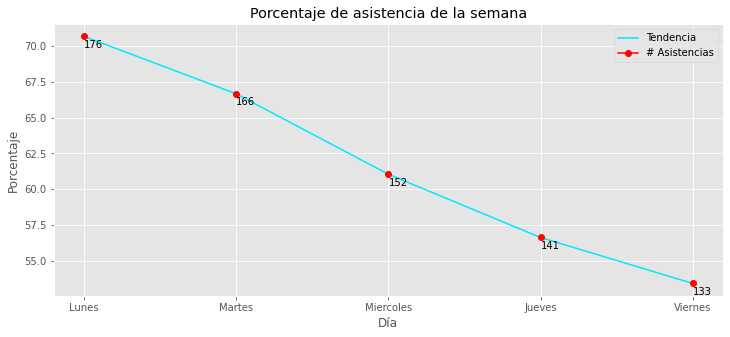

```python
# Tamanio del grafico de 12px de largo por 5px de ancho
fig = plt.figure(figsize=(12,5))

# Grafico de dias versus porcentajes de asistencias
# Creara un grafico de lineas:
plt.plot(dias, porcentajes, color="#00E9FE")

# Graficaremos cada uno de los puntos (Lunes, 70.68),
# (Martes, 66.67), etc
for i in range(5):
    plt.plot(dias[i], porcentajes[i], marker="o", color="#FE0404")
    # Mostraremos etiquetas de texto en nuestro grafico
    # que contengan la informacion del numero de
    # asistencias totales por cada dia
    plt.text(dias[i], porcentajes[i]-0.8, asistencias_num[i])

plt.legend(["Tendencia", "# Asistencias"])
plt.ylabel("Porcentaje")
plt.xlabel("Día")
plt.title("Porcentaje de asistencia de la semana")
plt.show()
```

Veamos ahora qué tan constantes fueron los alumnos. Para ello, sumaremos los valores de las columnas 6-10 para cada fila, esto es, veremos cuántas asistencias obtuvo cada estudiante y los clasificaremos. Recordemos que cada fila representa a un estudiante, de tal manera, si ahora sumamos por filas obtendremos el número total de asistencias por cada estudiante

```python
# Dado que la suma la hacemos ahora por filas,
# entonces escribimos sum(axis=1)
asis_por_alumno = asistencias.sum(axis=1)

# Convertimos lo anterior a un dataframe
asis_por_alumno = pd.DataFrame(asis_por_alumno)
asis_por_alumno
```

|  | 0 |
| --- | --- |
| 0 | 1.0 |
| 1 | 0.0 |
| 2 | 5.0 |
| 3 | 4.0 |
| 4 | 4.0 |
| ... | ... |
| 256 | 4.0 |
| 257 | 5.0 |
| 258 | 2.0 |
| 259 | 1.0 |
| 260 | 0.0 |

249 rows × 1 columns

Lo anterior no es tan visual. Para entender mejor la información anterior clasificaremos a los alumnos por aquellos que obtuvieron 0 asistencias, 1 asistencia, etcétera.

Lo anterior lo conseguiremos utilizando el método `value_counts()` que identifica los distintos valores de una columna de un dataframe, y cuenta el número de apariciones de dichos valores. Por ejemplo, en el dataframe `asis_por_alumno` identificamos los distintos valores 0,1,2,3,4 y 5, luego, se contará cuántas veces apareció en dicha columna el valor 0, cuántas veces apareció en dicha columna el valor 1, etcétera. Así:

```python
asis_por_alumno.value_counts()
```

```
5.0    103
0.0     55
4.0     41
1.0     23
2.0     15
3.0     12
dtype: int64
```

que nos dice que en total:

- 103 alumnos asistieron los cinco días de la semana al curso.
- 41 alumnos asistieron cuatro días al curso.
- 12 alumnos asistieron tres días al curso.
- 15 alumnos asistieron dos días al curso.
- 23 alumnos asistieron un día al curso.
- 55 alumnos no asistieron ningún día de la semana al curso.

Con base en lo anterior podemos construir la siguiente gráfica

```python
# Obtengamos el total de asistencias por cada
# dia y guardemoslo en una lista auxiliar
num_group = []
for i in range(6):
    num_group.append(asis_por_alumno.value_counts()[i])
num_group
```

```
[55, 23, 15, 12, 41, 103]
```

donde

| Número de asistencias | Total de alumnos | Índice en la lista num_group |
| --- | --- | --- |
| 0 | 55 | 0 |
| 1 | 23 | 1 |
| 2 | 15 | 2 |
| 3 | 12 | 3 |
| 4 | 41 | 4 |
| 5 | 103 | 5 |

Continuando

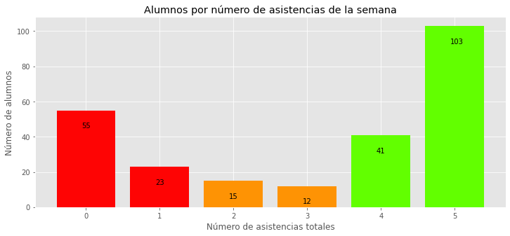

```python
fig = plt.figure(figsize=(12,5))

# Numeros posibles de asistencias de la semana para cada alumno
lista_asistencias = [0, 1, 2, 3, 4, 5]

# Graficamos
colores = ["#FE0404", "#FE0404","#FE9304", "#FE9304", "#62FF00", "#62FF00"]
#       Lista de posibles| numero total de alumnos
#       asistencias      | con ese numero de
#       (0,1,2,3,4,5)    | asistencias
plt.bar(lista_asistencias, num_group, color=colores)

# Agregamos un texto informativo con el total de alumnos
# que asistieron 5 dias, 4, etc
for i in range(6):
    plt.text(i-0.06, num_group[i]-10, num_group[i], color="black")

plt.xlabel("Número de asistencias totales")
plt.ylabel("Número de alumnos")
plt.title("Alumnos por número de asistencias de la semana")
plt.show()
```

Notamos que bastantes alumnos no obtuvieron ninguna asistencia en la semana; unos pocos alumnos tuvieron entre 2 y 3 asistencias en la semana y, la mayoría, fue constante con sus asistencias al tener entre 4 y 5 asistencias.

Hemos abordado ya las cuestiones que planteamos al inicio, por lo cual el análisis ha terminado. Con todo lo anterior nos damos una idea intuitiva de cómo realizar un pequeño análisis sobre los datos que sean de interés, además, el primer paso siempre debe ser explorar los datos (también de manera gráfica si es posible) para así ver algunas estadísticas, ver la "naturaleza" de nuestros datos, ver si hay datos faltantes o si debemos realizar algunas modificaciones (limpieza de datos). Una vez hecho lo anterior podremos indagar en las cuestiones que se nos han planteado y, ahora sí, realizar un análisis sobre nuestros datos.